# Envisioning a Different Product-Engineering Contract

Ia Mgvdliashvili

### About Me

- Software Engineer: Full-Stack, Cloud & more
- Domains: Sound Research, BioTech, OCR
- Teaching, not just programming, but Tech Literacy for general audience

### What I want to share

- How I look at product-engineering contract
- Where AI can - and can’t - come in
- How we can redesign the flow and remove barriers

## State of AI for development

### How last year has felt

[figure not shown]

### Where I’m coming from

- XP/best-practices approach
- Ship quality, maintainable software
- Security practices

### How impactful is AI

- Day to day, small tasks - game-changer
- Prototypes - revolutionary
- Autonomous development - flaky claims of success

### Costs of pushing for autonomous development

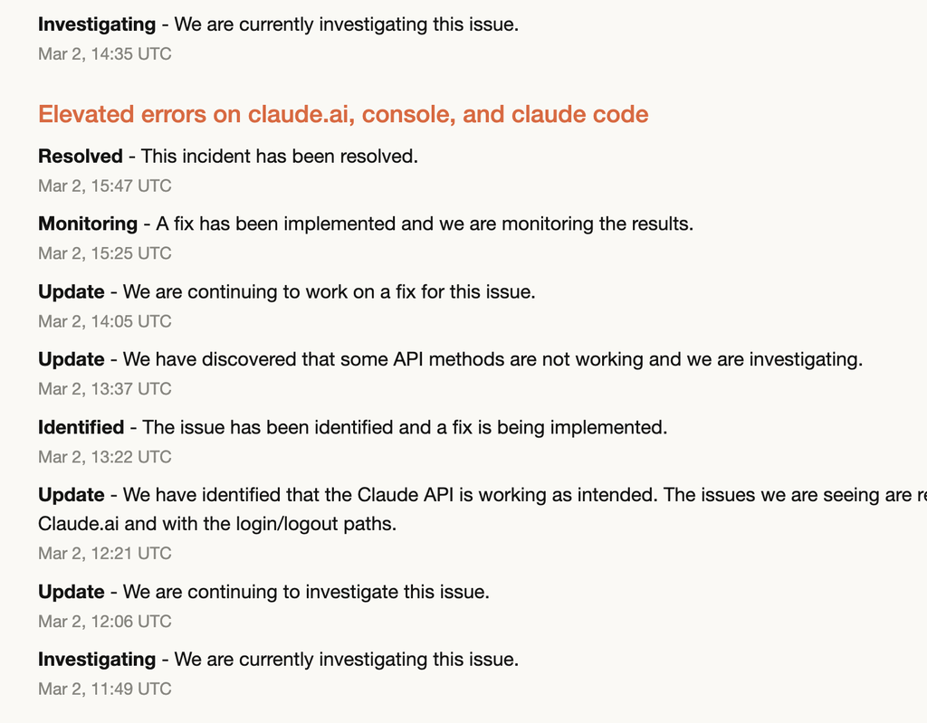

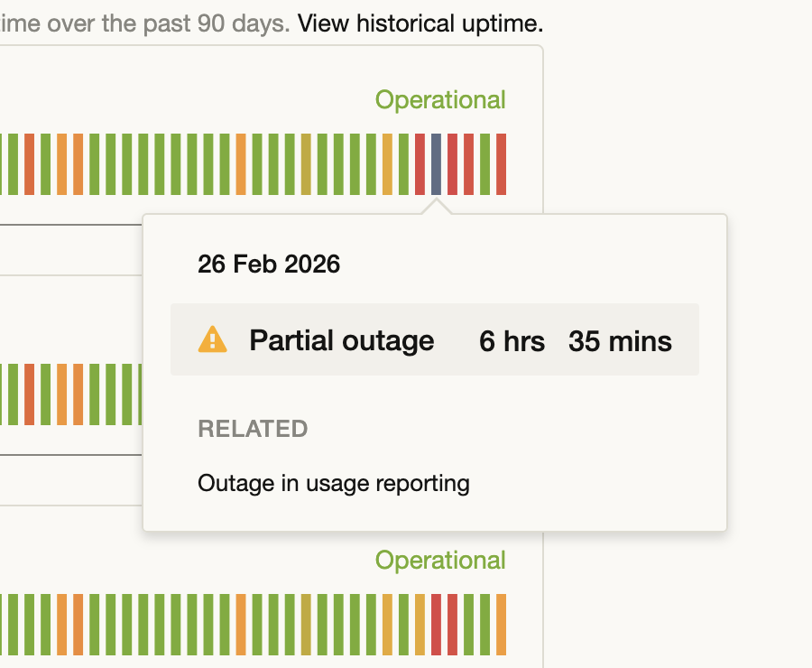

### The choice enterprises need to make

- Pressure to switch to a new, obscure paradigm
- Focus on authentic transformations

## Transforming the collaboration

### Current Status quo

[figure not shown]

### Prototyping

- Without engineering effort
- Rapid iterations

### Prototyping

With AI, we get to do

[figure not shown]

### Does this mean more features

not necessarily

## Can we extract more value?

Prototypes still take tremendous effort. Can we cascade more of it to rest of the development?

### Prototype =/= Specification

### What is TDD/ATDD

[figure not shown]

### How can a better flow look like

[figure not shown]

### Extended specification

Increase participation in engineering by

- specification
- acceptance tests
- synthetic data

## What engineering delivers

### Accessibility

- Ensure product has easy access to development environments
- Could mean a bigger comeback of browser sandbox IDEs

### Not just front-end

Disposable visualizations for back end features can be created with no effort. This is a big shift

### Invest in observability and alerting

- More inclusion, helps undertand the system
- Autonomous feedback on prototypes
- Assess impact independently

# Questions

Get in touch

`connect@iyamg.com`

[figure not shown]